# Algorithmic Privacy

Dominic Bordelon, Research Data Librarian  
University of Pittsburgh Library System

November 8, 2022

## Agenda

1. The story so far; why $k$-anonymity isn’t enough
2. Differential privacy
3. Mathematical formalism of differential privacy
4. Hands-on: examples from *Programming Differential Privacy* (Near and Abuah 2021)
5. Closing thoughts

# The story so far

## Classic approaches to data privacy

- Cryptography influences
- Suppression: not publishing
  - Suppressing an entire dataset
  - Suppressing particular fields; “de-identification” by dropping “PII” or “PHI”<sup>1</sup> columns
  - Suppressing particular subsets (e.g., very small groups)
[^1]: “Personally identifiable information” and “personal/protected health information”

## Classic approaches to data privacy

- Cryptography influences
- Suppression: not publishing
- Sampling: publishing “only” a subset of records
- Jittering by hand; swapping
- Generalization
  - Binning (age `54` $\rightarrow$ `50–60`), rounding
  - Publication of summary statistics and contingency tables

What are some shortcomings of these techniques?

## MA Gov. Weld re-identification (1997)

- Latanya Sweeney, then-PhD student at MIT, discovered state employees’ health records would be released (de-identified but with gender, DOB, zip code remaining)
- “A mental calculation surprised me: There are 365 days in a year, two *[sic]* genders, and people live about 78 years. Multiplying these numbers gives **56,940 unique combinations**. However, the average five-digit ZIP code in the United States has only about **25,000 people**.” (Sweeney 2015)
- Governor William Weld’s DOB, gender, and zip code were unique in voter rolls (available for $20) and in the de-identified release, allowing him to be re-identified by Sweeney—example of a *re-identification attack*
- HIPAA (Health Insurance Portability and Accountability Act) subsequently adopted a Privacy Rule which continues to be updated
  - Example: where a zip code appears, only first three digits may be reported publicly
- Subsequent experiments by Sweeney were court-sealed, and she had difficulty publishing and obtaining funding

## The concept of $k$-anonymity

- $k$ answers the question, for a given row in a dataset, how many other rows are identical?
- Or: when grouping by every variable, what is the smallest group size?
- $k = 1$ when there exists one unique record in the dataset (i.e., at least one record is uniquely identifiable, so there is no guarantee of privacy)
- If you are in the dataset, and $k = 10$, you are indistinguishable from 9 other participants; therefore, we want $k$ to be a high number
- Proposed by Samarati and Sweeney (1998)
- Since shown to *not* satisfy privacy needs on its own, but still a useful concept

## AOL search log release (2006)

- For three days in 2006, AOL made available a log file of ~20m queries of ~650k users for a 3-month period
- Only “PII” column was a numeric user ID
  - Some (even now) might naively consider these data to be anonymized!
- User Thelma Arnold (among others) was re-identified by The New York Times; publication of this breach, with Arnold’s permission, led to resignations and firings.
- Class-action lawsuit (settled 2013)

## The Netflix Prize (2006–2010)

- The Netflix Prize was a public contest by Netflix from 2006-2009 which had competitors use released, de-identified data about viewings in order to optimize Netflix’s recommendation algorithm.
- Narayanan and Shmatikov (2008) used the Netflix Prize training data, in combination with IMDB reviews and statistical analysis (“entropic de-anonymization”), in order to successfully link Netflix users to IMDB accounts.
- Netflix cancelled further iterations of the Prize and settled a lawsuit.
- By 2009-10 (time of the controversy), differential privacy had been formulated by Dwork et al. (2006), but was not in adoption yet.

## What can we learn from public records and a news story?

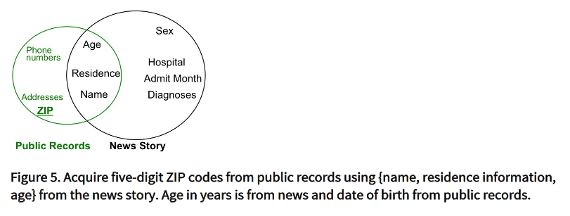

Source: Sweeney (2015)

## What can we also learn from obtainable hospital data?

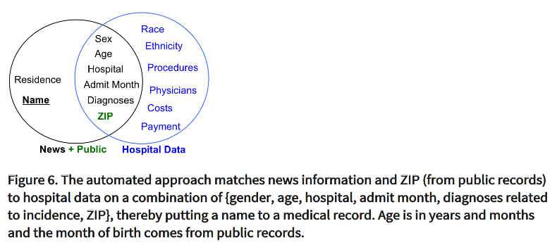

Source: Sweeney (2015)

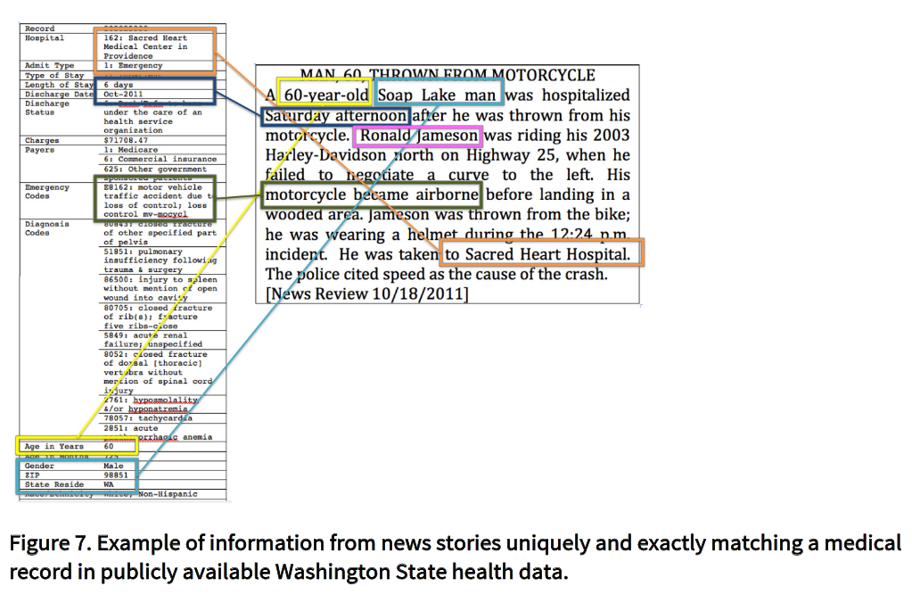

Source: Sweeney (2015)

## Genomic data privacy

Besides being based in relatively new technologies, genomics poses new privacy challenges…

- Necessarily sensitive and persistent information
- Raw data are not tabular (different algorithms, or transformation, may be needed)
- Use cases span ancestry tracing, forensics, medical diagnostics and screening—each with their own complex ethical issues
- A right to solitude: privacy “could include the right not to be (re)contacted about ancillary findings generated from genomic testing or discovery-driven investigations into existing genomic data sets or by previously unknown relatives” (Wan et al. 2022).

## Genomic data

A typical datum in this area is a single-nucleotide polymorphism (SNP), which is a difference in a single nucleotide of genetic code.

SNPs may or may not result in phenotypic differences—and many of them are in non-coding regions of DNA, anyway—but taken altogether, they form a unique “fingerprint.”

SNPs are the raw data; attacks often combine these data and accompanying metadata (e.g., patient’s demographic info).

## Single-nucleotide polymorphisms

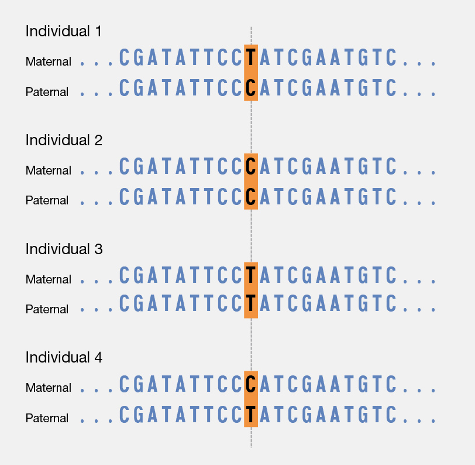

What a SNP looks like in genetic data.  
Source: [genome.gov](https://www.genome.gov/genetics-glossary/Single-Nucleotide-Polymorphisms)

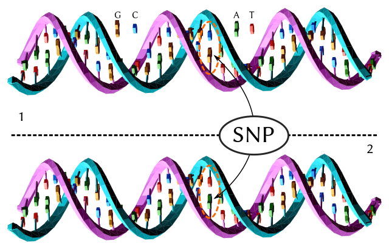

What SNPs look like in DNA.  
Source: [SNP model](https://commons.wikimedia.org/wiki/File:Dna-SNP.svg) by David Eccles (gringer), [CC BY 4.0](https://creativecommons.org/licenses/by/4.0)

## Types of genomic privacy intrusion

- Malin (2005) began applying the wider data privacy conversation to genomics, deploying four re-identification techniques:
  - Family structure (i.e., genomic + genealogical data) and combinatorics
  - Genotype-phenotype inference
  - “Trails” of geoinformation (e.g., location of study or hospital)
  - “Dictionary” attacks which decrypt simplistic privacy measures
- Erlich and Narayanan (2014) comprehensively outline vectors of attack in genetic data:
  - Identity tracing attacks: surname inference, DNA phenotyping, demographic identifiers, pedigree structure, side-channel leaks
  - Attribute disclosure attacks using DNA: n=1, genotype frequencies, linkage disequilibrium, effect sizes, trait inference, gene expression
  - Completion attacks: imputation of a masked marker, genealogical imputation of single or multiple relatives
- Wan et al. (2022) provide a very current and comprehensive review

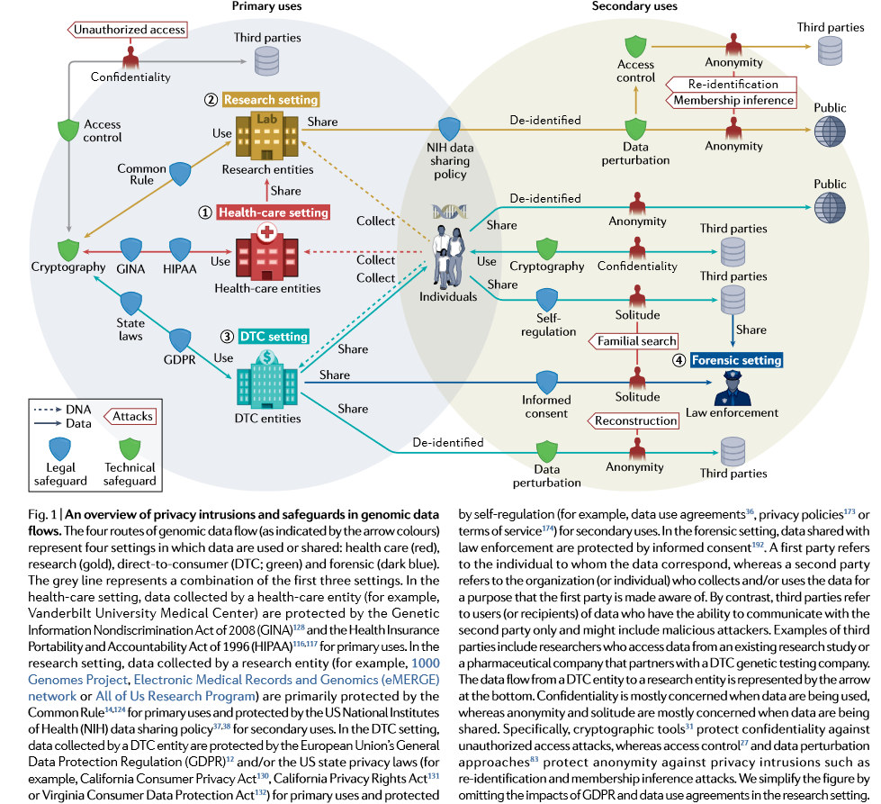

An overview of privacy intrusions and safeguards in genomic data flows in Wan et al. (2022)

## Privacy is a requirement for a democratic society

- Freedom of speech also entails freedom of thought (“intellectual freedom”)
- Knowing we’re being watched changes our behavior: self-censorship or “chilling effect”
- 2001 PATRIOT Act empowered law enforcement to (for example) more easily compel borrower records from libraries
  - Librarians’ response: sorry, we don’t retain those records!
- Given the big data we all generate, and the precise tools available to many industries such as health insurance and advertising, ought we not be concerned about privacy in all forms?

## Why $k$-anonymity isn’t enough

- Data may be published as $k$-anonymous, but can still be combined with other data to trace or re-identify an individual.
- Sweeney (2015) re-identified 43% of records studied (n = 81) in the preceding newspaper examples and using a state health database (exact, not probabilistic matches); confirmed with newspaper reporter
- $k$ is a *combinatorial* property; it can shrink from 100 to 1 quickly (as separate datasets are joined)
- So… which information is “sensitive”? Potentially all of it! Then how do we protect it?

# Differential privacy

## Differential privacy

- A guarantee: there are two adjacent databases, $D$ and $D'$. (Adjacent = same except for removal of one record, yours.) Given the ability to query both databases, an adversary won’t be able to determine (1) anything about you, nor (2) definitively determine whether you are a member of $D$ and/or $D'$ .
- Proposed in Dwork et al. (2006)
- Calculates for us the *right* amount of statistical perturbation (noise) to both:
  1. Protect against re-identification and tracing attacks
  2. Keep the same statistical qualities as the original data
- We can identify real-world correlations without jeopardizing any individual’s information or identity
- Believed to be future-proof (but Dwork still contends: “anonymized data, isn’t”).

## Differential privacy

> “Perhaps the most surprising property of differential privacy is that, despite its protective strength, it is compatible with meaningful data analysis.”

this is because

> “data snoopers are not interested in the population, rather, they are interested in this specific realization of data from the population, namely the database itself, $D$. . . . In a sense, $D$ is a population, and a data snooper is trying to learn about its fixed unknown parameters”

(Dwork et al. 2017; Matthews and Harel 2012)

## What *doesn’t* differential privacy protect against?

- Information the adversary knows from *outside* of the dataset
  - Example: Cancer study data won’t allow the adversary to see Bob’s information (e.g., whether he is a smoker), nor whether he’s even *in* the study. But they might find out that Bob is a smoker through other means.
  - However, because of DP perturbation, the adversary will not be able to join/cross-reference the study data with whatever they know about Bob.
- Application of inferences that an analyst generates from the dataset
  - If the data in the previous example show a correlation between smoking and incidence of lung cancer, the privacy regime does *not* prevent the adversary inferring that Bob is at a higher risk of lung cancer.

## Approaches to differential privacy

We can think about the topic of differential privacy in some different ways:

- What kind of risks are faced by the user? How does the proposed mechanism help?
- Is there a trusted curator of the data?
  - *central model* of DP: yes, there is a trusted curator with access to true data, who receives queries and serves results to an untrusted analyst
  - *local model* of DP: data nodes don’t trust anyone; DP is applied by the data creator before uploading to untrusted curator

## Approaches to differential privacy

We can think about the topic of differential privacy in some different ways:

- What kind of risks are faced by the user? How does the proposed mechanism help?
- Is there a trusted curator of the data?
- Which data are perturbed?
  - *input* techniques: modify underlying data $\rightarrow$ query/compute on faked data (local model)
  - *output* techniques: query/compute on real data $\rightarrow$ modify results before serving to analyst (central model)

## Approaches to differential privacy

We can think about the topic of differential privacy in some different ways:

- What kind of risks are faced by the user? How does the proposed mechanism help?
- Is there a trusted curator of the data?
- Which data are perturbed?
- Which perturbation mechanism is deployed: Gaussian, Laplace, exponential…
- What is the structure of the data (tabular, social network, imagery…), and how to comply with specific sociocultural requirements (e.g., protection against facial recognition adversaries)
- For a non-summarized data release, how to apply DP principles in order to synthesize fake data (which are nevertheless statistically valid samples of the population)

## Properties of differential privacy

- Sequential composition: “the $\epsilon$s add up”
  - $\epsilon =$ our privacy budget, determined by the curator (the symbol is a lowercase epsilon)
  - Sequential composition “bounds the total privacy cost of releasing multiple results of differentially private mechanisms on the same input data.” (Near and Abuah 2021)
  - More queries on a dataset $\rightarrow$ less privacy, as represented by the budget adding up
  - Given two mechanisms with budgets of 1 and 2 respectively, applying them sequentially results in a dataset with a total budget of 3: $\epsilon$-1 + $\epsilon$-2 = $\epsilon$-3
  - Each mechanism enforces its $\epsilon$ mathematically
  - Compare with $k$-anonymity, which changes multiplicatively—differential privacy is a stronger guarantee